# Day_4-after-lecture slides

## More on functions: `return` statement

### `return` vs `print`

Functions that `return` are easier to repurpose than those that `print` their result.

### Example

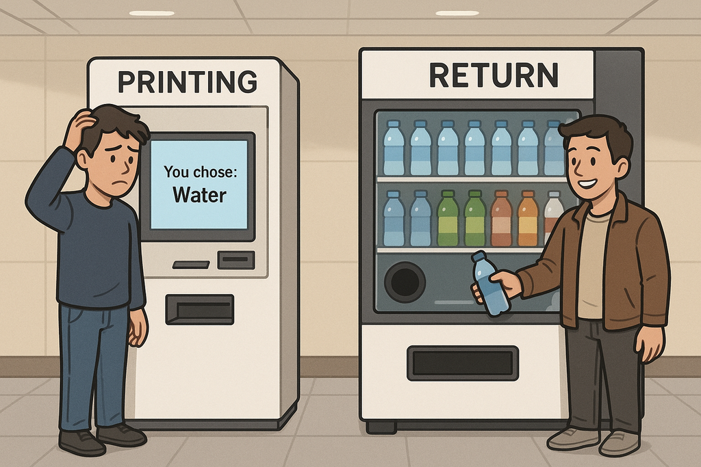

- **Print vending machine:** Only see an information. Cannot use the water
- **Return vending machine:** Have something real in your hands and can use it:
  - Drink it yourself (use the value)
  - Put it in your bag for later (store in a variable)
  - Give it to a friend (pass to another function)

A function that counts the number of occurrences of `'C'` in the argument string.

```python
def cytosine_count(nucleotides):
    count = 0
    for x in nucleotides:
        if x == 'c' or x == 'C':
            count += 1
    print(count)

count1 = cytosine_count('CATACTAC')
count2 = cytosine_count('tcgcag')
```

- Print the result

```python
print(f"{count1}\n{count2}")
```

- Repurpose the result: Sum the `'C'` occurrences

```python
total_count = count1 + count2
print(f"Total number of C: {total_count}")
```

#### Functions can return multiple values

```python
# Modify the function below for returning multiple values
def nucl_count(nucleotides):
    count_c = 0
    count_a = 0
    for x in nucleotides:
        if x == 'c' or x == 'C':
            count_c += 1
        if x == 'a' or x == 'A':
            count_a += 1
    return count_c, count_a

cyt, ade = nucl_count('aacccgt')
print(f"Numbers of C: {cyt} and number of A: {ade}")
```

#### Functions without any `return` statement returns `None`

```python
def foo():
    do_nothing = 1

result = foo()
print(f'Return value of foo() = {result}')
```

#### Return statement outcome

- Use `return` for all values that you might want to use later in your program or in simple words: **always**

## Small detour: Python's value for missing values: `None`

- Default value for optional arguments
- Implicit return value of functions without a `return` statement
- `None` is `None`, not anything else (special value).

```python
None == 0
```

```python
None == False
```

```python
None == ''
```

```python
type(None)
```